# Introduction to Spark

Monte Lunacek

[figure not shown]

## Landscape of Distributed Computing

[figure not shown]

[Many-Task Computing: Bridging the Gap between High Throughput Computing and High Performance Computing](http://datasys.cs.iit.edu/publications/2009_PhD-UChicago_dissertation.pdf)

How do you process 100's of GB of data?

- Filtering unstructured data
- Aggregation
- Large-scale machine learning
- Graph analysis

## Outline

- Functional programming in Python
- Hadoop's MapReduce
- Spark's programming model
- As many examples as we can get through!

## Functional Python

> Python acquired lambda, reduce, filter and map, courtesy of a Lisp hacker who missed them and submitted working patches. -Guido van Rossum
- `map`
- `reduce`
- `filter`
- `lambda`
- And more: [itertools](https://docs.python.org/2/library/itertools.html), [pytoolz](https://github.com/pytoolz/toolz/)

We will use these concepts (and more) in `Spark`

### The `map` abstraction

```python
def square(x):
    return x*x

numbers = [1,2,3]

def map_squares(nums):
    res = []
    for x in nums:
        res.append( square(x) )
    return res
```

or...

```python
results = map(square, numbers)
```

For parallel computing in python, `map` is a key abstraction.

```python
from multiprocessing import Pool
pool = Pool(5)
results = pool.map(square, numbers)
```

### `lambda`

Anonymous function: a function without a name

```python
lambda_square = lambda x: x*x
map(lambda_square, range(10))
```

```
[0, 1, 4, 9, 16, 25, 36, 49, 64, 81]
```

```python
map(lambda x: x*x, range(10))
```

```
[0, 1, 4, 9, 16, 25, 36, 49, 64, 81]
```

```python
res = map(lambda x: x*x, range(10))
print res
```

```
[0, 1, 4, 9, 16, 25, 36, 49, 64, 81]
```

### `reduce`

Apply a function with **two** arguments cumulatively to the container.

```python
def add_num(x1, x2):
    return x1+x2

print reduce(add_num, res)
```

```
285
```

```python
print reduce(lambda x,y: x+y, res)
```

```
285
```

### `filter`

Constructs a new list for items where the applied function is `True`.

```python
def less_than(x):
    return x>10

filter(less_than, res)
```

```
[16, 25, 36, 49, 64, 81]
```

```python
filter(lambda x: x>10, res)
```

```
[16, 25, 36, 49, 64, 81]
```

## Data Storage

[Hadoop Definitive Guide](http://www.amazon.com/Hadoop-Definitive-Guide-Tom-White/dp/1449311520) by Thom White

- Access speeds are not keeping up with capacity
- HDFS motivation: e.g 100 MB/s

[figure not shown]

## MapReduce

[MapReduce: Simplified Data Processing on Large Clusters](http://research.google.com/archive/mapreduce.html)

Kernel programming model for working with distributed data.

[figure not shown]

- Inefficiencies with MapReduce

## Spark

[figure not shown]

## Overview

[figure not shown]

- Spark: same code runs locally or on a cluster.

## Spark Programming Model

Everything starts with a `SparkContext`

```python
from pyspark import  SparkContext

if 'sc' not in globals():
    sc = SparkContext(CLUSTER_URL,'example')
```

This [gist](http://nbviewer.ipython.org/gist/fperez/6384491/00-Setup-IPython-PySpark.ipynb) by Fernando Perez explains how to initialize the `CLUSTER_URL` during the startup of IPython.

- local
- URL for a distributed cluster

```python
print CLUSTER_URL # could be 'local'
```

```
spark://node1239:7077
```

### Create RDDs

[RDD Documentation](http://spark.apache.org/docs/0.7.0/api/pyspark/pyspark.rdd.RDD-class.html)

The `parallelize` method is a utility for initializing RDDs.

- Not efficient (it writes a file and reads back in).

```python
import numpy as np

rdd = sc.parallelize(np.arange(20), numSlices=5)
```

### Transformations and Actions

**Actions** return values

- `collect`
- `reduce`
- `take`
- `count`

**Transformations** return pointers to new RDDs

- `map`, `flatmap`
- `reduceByKey`
- `filter`
- `glom`

What does this look like?

- `glom`: Returns an RDD list from each partition of an RDD.
- `collect`: Returns a list from all elements of an RDD.

```python
for x in rdd.glom().collect():
    print x
```

```
[0, 1, 2, 3]
[4, 5, 6, 7]
[8, 9, 10, 11]
[12, 13, 14, 15]
[16, 17, 18, 19]
```

```python
rdd = sc.parallelize(np.arange(20), numSlices=10)
for x in rdd.glom().collect():
    print x
```

```
[0, 1]
[2, 3]
[4, 5]
[6, 7]
[8, 9]
[10, 11]
[12, 13]
[14, 15]
[16, 17]
[18, 19]
```

### `map` and `Flatmap`

Return a new RDD by first applying a function and then flattening the results.

```python
rdd = sc.parallelize([ [2, 3, 4],[0, 1],[5, 6, 7, 8] ])
rdd.collect()
```

```
[[2, 3, 4], [0, 1], [5, 6, 7, 8]]
```

```python
rdd.map(lambda x: range(len(x))).collect()
```

```
[[0, 1, 2], [0, 1], [0, 1, 2, 3]]
```

Or I can flatten the results...

```python
rdd.flatMap(lambda x: range(len(x))).collect()
```

```
[0, 1, 2, 0, 1, 0, 1, 2, 3]
```

Or flatten the original results

```python
rdd.flatMap(lambda x: x).collect()
```

```
[2, 3, 4, 0, 1, 5, 6, 7, 8]
```

### Reduction

```python
rdd.flatMap(lambda x: x).reduce(lambda x,y: x+y)
```

```
36
```

```python
rdd = sc.parallelize([("a", 1), ("b", 1), ("a", 2)])
rdd.collect()
```

```
[('a', 1), ('b', 1), ('a', 2)]
```

```python
rdd.reduceByKey(lambda x,y: x+y).collect()
```

```
[('b', 1), ('a', 3)]
```

```python
rdd = sc.parallelize([("hamlet", 1), ("claudius", 1), ("hamlet", 1)])
```

```python
rdd.countByKey()
```

```
defaultdict(<type 'int'>, {'claudius': 1, 'hamlet': 2})
```

# Send the Computation to the Data

Create some work to do.

```python
import time
import os

def work(x):
    start_time = time.time()
    time.sleep(x)
    end_time =  time.time()
    return {'id': os.getpid(), 'start': start_time, 'end_time': end_time}
```

Create a a `list` of work times

```python
import numpy as np

np.random.seed(1045)
job_times = np.random.uniform(0.4, 0.6, 240)
```

How long should it take?

```python
print 'Estimated serial time = {0:0.2f}'.format(job_times.sum())
print 'Amdahls parallel time = {0:0.2f}'.format(job_times.sum()/12.)
```

```
Estimated serial time = 119.80
Amdahls parallel time = 9.98
```

Helper plot function.

```python
%matplotlib inline
import matplotlib.pyplot as plt
import pandas as pd

def plot_workflow(results):
    res = pd.DataFrame(results)
    ids = list(set(res['id']))
    id_dic = dict( [k,v+0.65] for k,v in zip(ids, range(len(ids))))
    fig, ax = plt.subplots(figsize=(8, 6))

    tmin = res['start'].min()
    for i in res.index:
        x_start = res.ix[i]['start'] - tmin
        x_end = res.ix[i]['end_time'] - tmin - x_start
        x_id = id_dic[res.ix[i]['id']]
        ax.add_patch(plt.Rectangle((x_start, x_id),
                                   x_end, 0.8,
                                   alpha=0.5,
                                   color='grey'))

    ax.set_ylim(0.5, len(ids)+0.5)
    ax.set_xlim(0, res['end_time'].max() - tmin)
    ax.set_ylabel("Worker")
    ax.set_xlabel("seconds")
```

## Run in parallel with `spark`

```python
from pyspark import  SparkContext
sc = SparkContext( CLUSTER_URL, 'pyspark')
```

```python
jobs = sc.parallelize(job_times)
print jobs.count()
results = jobs.map(work)
%time res = results.collect()
```

```
240
CPU times: user 4 ms, sys: 3 ms, total: 7 ms
Wall time: 10.6 s
```

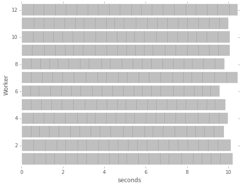

```python
plot_workflow(res)
```

# Simple Aggregation

```python
import numpy as np

data = np.arange(1000).reshape(100,10)
print data.shape
```

```
(100, 10)
```

## Pandas

```python
import pandas as pd

tmp = pd.DataFrame(data,
             columns=['x{0}'.format(i) for i in range(data.shape[1])])
tmp.head()
```

|  | x0 | x1 | x2 | x3 | x4 | x5 | x6 | x7 | x8 | x9 |
| --- | --- | --- | --- | --- | --- | --- | --- | --- | --- | --- |
| 0 | 0 | 1 | 2 | 3 | 4 | 5 | 6 | 7 | 8 | 9 |
| 1 | 10 | 11 | 12 | 13 | 14 | 15 | 16 | 17 | 18 | 19 |
| 2 | 20 | 21 | 22 | 23 | 24 | 25 | 26 | 27 | 28 | 29 |
| 3 | 30 | 31 | 32 | 33 | 34 | 35 | 36 | 37 | 38 | 39 |
| 4 | 40 | 41 | 42 | 43 | 44 | 45 | 46 | 47 | 48 | 49 |

5 rows × 10 columns

What is the row sum?

```python
tmp.sum(axis=1)
```

```
0       45
1      145
2      245
3      345
4      445
5      545
6      645
7      745
8      845
9      945
10    1045
11    1145
12    1245
13    1345
14    1445
```

[output cut: 17 more lines]

```python
tmp.sum(axis=0)
```

```
x0    49500
x1    49600
x2    49700
x3    49800
x4    49900
x5    50000
x6    50100
x7    50200
x8    50300
x9    50400
dtype: int64
```

```python
tmp.to_csv('numbers.csv', index=False)
```

## Spark

```python
from pyspark import  SparkContext

if 'sc' not in globals():
    sc = SparkContext( CLUSTER_URL, 'pyspark')
```

```python
lines = sc.textFile('numbers.csv')
for l in lines.take(2):
    print l
```

```
x0,x1,x2,x3,x4,x5,x6,x7,x8,x9
0,1,2,3,4,5,6,7,8,9
```

How do we skip the header?

```python
lines = lines.filter(lambda x: x.find('x') != 0)
for l in lines.take(2):
    print l
```

```
0,1,2,3,4,5,6,7,8,9
10,11,12,13,14,15,16,17,18,19
```

```python
data = lines.map(lambda x: x.split(','))
data.take(3)
```

```
[[u'0', u'1', u'2', u'3', u'4', u'5', u'6', u'7', u'8', u'9'],
 [u'10', u'11', u'12', u'13', u'14', u'15', u'16', u'17', u'18', u'19'],
 [u'20', u'21', u'22', u'23', u'24', u'25', u'26', u'27', u'28', u'29']]
```

### Row Sum

```python
def row_sum(x):
    int_x = map(lambda x: int(x), x)
    return sum(int_x)

data_row_sum = data.map(row_sum)

print data_row_sum.collect()
print data_row_sum.count()
```

```
[45, 145, 245, 345, 445, 545, 645, 745, 845, 945, 1045, 1145, 1245, 1345, 1445, 1545, 1645, 1745, 1845, 1945, 2045, 2145, 2245, 2345, 2445, 2545, 2645, 2745, 2845, 2945, 3045, 3145, 3245, 3345, 3445, 3545, 3645, 3745, 3845, 3945, 4045, 4145, 4245, 4345, 4445, 4545, 4645, 4745, 4845, 4945, 5045, 5145…
100
```

### Col Sum

```python
def col_key(x):
    for i, value in enumerate(x):
       yield (i, int(value))

tmp = data.flatMap(col_key)
tmp.take(3)
```

```
[(0, 0), (1, 1), (2, 2)]
```

```python
tmp = tmp.groupByKey()
for i in tmp.take(2):
    print i
```

```
(0, [0, 10, 20, 30, 40, 50, 60, 70, 80, 90, 100, 110, 120, 130, 140, 150, 160, 170, 180, 190, 200, 210, 220, 230, 240, 250, 260, 270, 280, 290, 300, 310, 320, 330, 340, 350, 360, 370, 380, 390, 400, 410, 420, 430, 440, 450, 460, 470, 480, 490, 500, 510, 520, 530, 540, 550, 560, 570, 580, 590, 600, 6…
(1, [1, 11, 21, 31, 41, 51, 61, 71, 81, 91, 101, 111, 121, 131, 141, 151, 161, 171, 181, 191, 201, 211, 221, 231, 241, 251, 261, 271, 281, 291, 301, 311, 321, 331, 341, 351, 361, 371, 381, 391, 401, 411, 421, 431, 441, 451, 461, 471, 481, 491, 501, 511, 521, 531, 541, 551, 561, 571, 581, 591, 601, 6…
```

```python
data_col_sum = tmp.map(lambda x: sum(x[1]))
for i in data_col_sum.take(2):
    print i
```

```
49500
49600
```

```python
print data_col_sum.collect()
print data_col_sum.count()
```

```
[49500, 49600, 49700, 49800, 49900, 50000, 50100, 50200, 50300, 50400]
10
```

# Word Count

```python
%%writefile awsdata.py
import os
import urllib

def get(f):
    filename = f.split('/')[-1]
    #print filename
    if not os.path.exists(filename):
        print 'fetching from aws'
        urllib.urlretrieve(f, filename=filename)
```

```
Overwriting awsdata.py
```

```python
import awsdata
hamlet = awsdata.get('https://s3.amazonaws.com/research_computing_tutorials/hamlet.txt')
```

[output not shown]

## Standard Python

```python
import re

words = re.split('\W+', hamlet.lower().strip())
print words[:10]
```

```
['hamlet', 'dramatis', 'personae', 'claudius', 'king', 'of', 'denmark', 'king', 'claudius', 'hamlet']
```

```python
words = filter(lambda x: len(x)>2, words)
print words[:10]
```

```
['hamlet', 'dramatis', 'personae', 'claudius', 'king', 'denmark', 'king', 'claudius', 'hamlet', 'son']
```

```python
wc = dict()

def add_to_dic(word):
    wc[word] = wc.get(word,0) + 1

# map the words
map(add_to_dic, words)

#sort by frequency
top_words = sorted(wc.items(), key=lambda x: x[1], reverse=True)[:15]
```

```python
top_words
```

```
[('the', 930),
 ('and', 843),
 ('you', 496),
 ('hamlet', 368),
 ('that', 346),
 ('lord', 278),
 ('not', 262),
 ('his', 238),
 ('this', 238),
 ('with', 232),
 ('but', 232),
 ('for', 215),
 ('your', 211),
 ('what', 186),
 ('king', 171)]
```

```python
%matplotlib inline
import matplotlib.pyplot as plt

def plot(words):
    values = map(lambda x: x[1], words)
    labels = map(lambda x: x[0], words)
    plt.barh(range(len(values)), values, color='grey')
    plt.yticks(range(len(values)), labels)
    plt.show()
```

```python
plot(top_words)
```

[output not shown]

## Spark

```python
from pyspark import  SparkContext

if 'sc' not in globals():
    # CLUSTER_URL set during startup
    sc = SparkContext( CLUSTER_URL, 'pyspark')
```

```python
words = sc.textFile('hamlet.txt')
words.take(5)
```

```
[u'\tHAMLET', u'', u'', u'\tDRAMATIS PERSONAE', u'']
```

```python
hamlet = words.flatMap(lambda line: re.split('\W+', line.lower().strip()))
hamlet.take(5)
```

```
[u'hamlet', u'', u'', u'dramatis', u'personae']
```

```python
tmp = hamlet.filter(lambda x: len(x) > 2 )
print tmp.take(5)
```

```
[u'hamlet', u'dramatis', u'personae', u'claudius', u'king']
```

```python
tmp = tmp.map(lambda word: (word, 1))
tmp.take(5)
```

```
[(u'hamlet', 1),
 (u'dramatis', 1),
 (u'personae', 1),
 (u'claudius', 1),
 (u'king', 1)]
```

```python
tmp = tmp.reduceByKey(lambda a, b: a + b)
tmp.take(5)
```

```
[(u'partial', 1), (u'lean', 1), (u'peruse', 1), (u'leads', 1), (u'sleep', 11)]
```

```python
tmp = tmp.map(lambda x: (x[1], x[0])).sortByKey(False)
tmp.take(20)
```

```
[(930, u'the'),
 (843, u'and'),
 (496, u'you'),
 (368, u'hamlet'),
 (346, u'that'),
 (278, u'lord'),
 (262, u'not'),
 (238, u'his'),
 (238, u'this'),
 (232, u'with'),
 (232, u'but'),
 (215, u'for'),
 (211, u'your'),
 (186, u'what'),
 (171, u'king'),
 (160, u'him'),
 (149, u'have'),
 (134, u'will'),
 (124, u'polonius'),
 (112, u'horatio')]
```

```python
tmp = tmp.map(lambda x: (x[1], x[0]))
tmp.take(20)
```

```
[(u'the', 930),
 (u'and', 843),
 (u'you', 496),
 (u'hamlet', 368),
 (u'that', 346),
 (u'lord', 278),
 (u'not', 262),
 (u'his', 238),
 (u'this', 238),
 (u'with', 232),
 (u'but', 232),
 (u'for', 215),
 (u'your', 211),
 (u'what', 186),
 (u'king', 171),
 (u'him', 160),
 (u'have', 149),
 (u'will', 134),
 (u'polonius', 124),
 (u'horatio', 112)]
```

```python
plot(tmp.take(15))
```

[output not shown]

```python
plot(top_words)
```

[output not shown]

## Summary code

```python
words = sc.textFile('hamlet.txt')\
        .flatMap(lambda line: re.split('\W+', line.lower().strip()))\
        .filter(lambda x: len(x) > 2 )\
        .map(lambda word: (word, 1))\
        .reduceByKey(lambda a, b: a + b)\
        .map(lambda x: (x[1], x[0])).sortByKey(False)

words.take(15)
```

```
[(930, u'the'),
 (843, u'and'),
 (496, u'you'),
 (368, u'hamlet'),
 (346, u'that'),
 (278, u'lord'),
 (262, u'not'),
 (238, u'his'),
 (238, u'this'),
 (232, u'with'),
 (232, u'but'),
 (215, u'for'),
 (211, u'your'),
 (186, u'what'),
 (171, u'king')]
```

## Text filtering

```python
words = sc.textFile('hamlet.txt')
```

How many lines contains *hamlet*?

```python
tmp = words.filter(lambda x: "hamlet" in x.lower())
tmp.count()
```

```
367
```

As a percent?

```python
'{0:0.2f}%'.format(100*tmp.count()/float(words.count()))
```

```
'7.26%'
```

How about *claudius* and *hamlet*?

```python
tmp.filter( lambda x: 'claudius' in x.lower()).count()
```

```
12
```

```python
tmp.filter( lambda x: 'claudius' in x.lower()).collect()
```

```
[u'\t[Enter KING CLAUDIUS, QUEEN GERTRUDE, HAMLET,',
 u"KING CLAUDIUS\tThough yet of Hamlet our dear brother's death",
 u"KING CLAUDIUS\t'Tis sweet and commendable in your nature, Hamlet,",
 u'KING CLAUDIUS\tHow fares our cousin Hamlet?',
 u'KING CLAUDIUS\tI have nothing with this answer, Hamlet; these words',
 u'KING CLAUDIUS\tWhat, Gertrude? How does Hamlet?',
 u"KING CLAUDIUS\tNow, Hamlet, where's Polonius?",
 u'KING CLAUDIUS\tHamlet, this deed, for thine especial safety,--',
 u'KING CLAUDIUS\tAy, Hamlet.',
 u'KING CLAUDIUS\tThy loving father, Hamlet.',
 u'KING CLAUDIUS\tFrom Hamlet! who brought them?',
 u"KING CLAUDIUS\t'Tis Hamlets character. 'Naked!"]
```

# K-means

Based on the [spark examples](https://github.com/apache/spark/blob/master/examples/src/main/python/kmeans.py).

```python
import os
import numpy as np
```

Create input file.

```python
N = 5
num_points = 100

set1 = np.reshape(5 + np.random.randn(num_points*N), (num_points,N))
set2 = np.reshape(10 + np.random.randn(num_points*N), (num_points,N))
set3 = np.reshape(15 + np.random.randn(num_points*N), (num_points,N))

x = np.concatenate([set1, set2, set3])

np.savetxt('points.txt', x, delimiter=',', fmt='%10.5f')
```

## Using `sklearn`

```python
from sklearn.cluster import KMeans
from sklearn.metrics.pairwise import euclidean_distances

data = np.loadtxt('points.txt', delimiter=',')
k_means = KMeans(init='k-means++', n_clusters=3, n_init=10)
k_means.fit(data)
```

```
KMeans(copy_x=True, init='k-means++', max_iter=300, n_clusters=3, n_init=10,
    n_jobs=1, precompute_distances=True, random_state=None, tol=0.0001,
    verbose=0)
```

```python
def plot(centers):
    %matplotlib inline
    import matplotlib.pyplot as plt
    for i in range(3):
        plt.plot(centers[i])
```

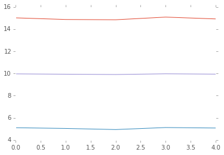

```python
plot(k_means.cluster_centers_)
```

## Using `numpy`

```python
def closest_point(p, centers):
    dist = map(lambda x: np.sum((p - x) ** 2), centers)
    return np.argmin(dist)
```

What is the closest center?

```python
centers = data[:3].copy()
closets_center = partial(closest_point, centers=centers)
tmp = map(closets_center, data)

print tmp[:10]
```

```
[0, 1, 2, 0, 1, 2, 1, 1, 1, 1]
```

Iterate

```python
k_points = data[:3].copy()

for i in range(30):
    closets_center = partial(closest_point, centers=k_points)
    tmp = np.array(map(closets_center, data))
    for i in range(len(centers)):
        k_points[i] = np.mean(data[tmp==i])
```

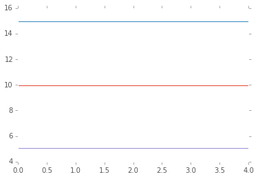

```python
plot(k_points)
```

## Spark

```python
from pyspark import  SparkContext
SparkContext.setSystemProperty('spark.executor.memory', '20g')

if 'sc' not in globals():
    sc = SparkContext( CLUSTER_URL, 'pyspark')
```

Convert line to `numpy` array of floats.

```python
def parseVector(line):
    return np.array([float(x) for x in line.strip().split(',')])
```

```python
lines = sc.textFile('points.txt')
lines.take(2)
```

```
[u'   3.94795,   5.24514,   4.21983,   5.82014,   3.56495',
 u'   4.12071,   5.60875,   4.98164,   3.79047,   5.37827']
```

```python
data = lines.map(parseVector).cache()
print data.count()
```

```
300
```

```python
data.first()
```

```
array([ 3.94795,  5.24514,  4.21983,  5.82014,  3.56495])
```

```python
k_points = data.take(3)
temp_dist = 1.0

closest = data.map(
    lambda p : (closest_point(p, k_points), (p, 1)))
closest.take(2)
```

```
[(0, (array([ 3.94795,  5.24514,  4.21983,  5.82014,  3.56495]), 1)),
 (1, (array([ 4.12071,  5.60875,  4.98164,  3.79047,  5.37827]), 1))]
```

```python
point_stats = closest.reduceByKey(
    lambda (x1, y1), (x2, y2): (x1 + x2, y1 + y2))
point_stats.take(2)
```

```
[(0,
  (array([ 203.28924,  195.7836 ,  188.10686,  233.8193 ,  178.81389]), 40)),
 (1,
  (array([ 2758.36735,  2753.10089,  2742.10208,  2743.79008,  2764.49942]),
   251))]
```

```python
new_points = point_stats.map(
    lambda (x, (y, z)): (x, y / z)).collect()
print new_points
```

```
[(0, array([ 5.082231  ,  4.89459   ,  4.7026715 ,  5.8454825 ,  4.47034725])), (1, array([ 10.98951135,  10.96852944,  10.92470948,  10.93143458,  11.01394191])), (2, array([ 5.15993444,  3.87556556,  4.26854111,  4.40604556,  5.57423444]))]
```

```python
temp_dist = sum(map(lambda (x,y): np.sum((k_points[x] - y) ** 2),
                new_points))

for (x, y) in new_points:
    k_points[x] = y
```

```python
for x in k_points:
    print x[:5]
```

```
[ 5.082231    4.89459     4.7026715   5.8454825   4.47034725]
[ 10.98951135  10.96852944  10.92470948  10.93143458  11.01394191]
[ 5.15993444  3.87556556  4.26854111  4.40604556  5.57423444]
```

## Summary

```python
lines = sc.textFile('points.txt')
data = lines.map(parseVector).cache()

k_points = data.take(3)
temp_dist = 1.0

while temp_dist > 0.001:

    closest = data.map(
        lambda p : (closest_point(p, k_points), (p, 1)))

    point_stats = closest.reduceByKey(
        lambda (x1, y1), (x2, y2): (x1 + x2, y1 + y2))

    new_points = point_stats.map(
        lambda (x, (y, z)): (x, y / z)).collect()

    temp_dist = sum(map(lambda (x,y): np.sum((k_points[x] - y) ** 2),
                    new_points))

    for (x, y) in new_points:
        k_points[x] = y
```

```python
for x in k_points:
    print x[:5]
```

```
[ 9.9623807  9.931509   9.9043745  9.9688528  9.9388466]
[ 15.013431   14.8657509  14.8416114  15.0812099  14.9176245]
[ 5.1051483  5.0403859  4.9402722  5.1225752  5.0783431]
```

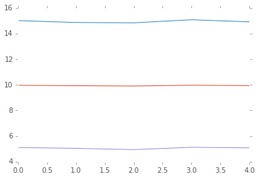

```python
plot(k_points)
```

```python
import awsdata
reload(awsdata)

awsdata.get('https://s3.amazonaws.com/research_computing_tutorials/movies.dat')
awsdata.get('https://s3.amazonaws.com/research_computing_tutorials/ratings.dat')
awsdata.get('https://s3.amazonaws.com/research_computing_tutorials/users.dat')
```

## Pandas

```python
import pandas as pd

def get_movie_data():

    unames = ['user_id','gender','age','occupation','zip']
    users = pd.read_table('users.dat',
                          sep='::', header=None, names=unames)

    rnames = ['user_id', 'movie_id', 'rating', 'timestamp']
    ratings = pd.read_table('ratings.dat',
                            sep='::', header=None, names=rnames)

    mnames = ['movie_id', 'title','genres']
    movies = pd.read_table('movies.dat',
                           sep='::', header=None, names=mnames)

    return users, ratings, movies
```

```python
users, ratings, movies = get_movie_data()
```

```python
print users.head()
```

```
   user_id gender  age  occupation    zip
0        1      F    1          10  48067
1        2      M   56          16  70072
2        3      M   25          15  55117
3        4      M   45           7  02460
4        5      M   25          20  55455

[5 rows x 5 columns]
```

```python
print ratings.head()
```

```
   user_id  movie_id  rating  timestamp
0        1      1193       5  978300760
1        1       661       3  978302109
2        1       914       3  978301968
3        1      3408       4  978300275
4        1      2355       5  978824291

[5 rows x 4 columns]
```

```python
print movies.head()
```

```
   movie_id                               title                        genres
0         1                    Toy Story (1995)   Animation|Children's|Comedy
1         2                      Jumanji (1995)  Adventure|Children's|Fantasy
2         3             Grumpier Old Men (1995)                Comedy|Romance
3         4            Waiting to Exhale (1995)                  Comedy|Drama
4         5  Father of the Bride Part II (1995)                        Comedy

[5 rows x 3 columns]
```

### Clean up

```python
tmp = movies.title.str.match('(.*) \(([0-9]+)\)')
movies['year'] = tmp.map(lambda x: x[1] if len(x) > 0 else None)
movies['short_title'] = tmp.map(lambda x: x[0][:40] if len(x) > 0 else None)
```

### Join

```python
data = pd.merge(pd.merge(ratings, users), movies)
```

### Compute

```python
tmp = data[['short_title','rating']]
grp = tmp.groupby('short_title')
mean_rating = grp['rating'].agg(['mean','count'])
print mean_rating.sort('mean', ascending=False).head(10)
```

```
                                        mean  count
short_title
Bittersweet Motel                   5.000000      1
Baby, The                           5.000000      1
Schlafes Bruder (Brother of Sleep)  5.000000      1
Hour of the Pig, The                5.000000      1
Ulysses (Ulisse)                    5.000000      1
Follow the Bitch                    5.000000      1
Smashing Time                       5.000000      2
Gate of Heavenly Peace, The         5.000000      3
I Am Cuba (Soy Cuba/Ya Kuba)        4.750000      4
Lamerica                            4.666667      6

[10 rows x 2 columns]
```

```python
mask = mean_rating['count'] > 1000
print mean_rating.ix[mask].sort('mean', ascending=False).head(10)
```

```
                                              mean  count
short_title
Shawshank Redemption, The                 4.554005   1935
Godfather, The                            4.527091   1901
Usual Suspects, The                       4.517949   1560
Schindler's List                          4.504985   2006
Raiders of the Lost Ark                   4.492847   2167
Star Wars: Episode IV - A New Hope        4.459961   2585
Dr. Strangelove or: How I Learned to Sto  4.443590   1170
Sixth Sense, The                          4.417228   2078
Casablanca                                4.409283   1422
One Flew Over the Cuckoo's Nest           4.390866   1489

[10 rows x 2 columns]
```

## Spark

```python
from pyspark import  SparkContext
SparkContext.setSystemProperty('spark.executor.memory', '20g')

if 'sc' not in globals():
    sc = SparkContext( CLUSTER_URL, 'pyspark')
```

```python
users = sc.textFile('users.dat').map(lambda x: (int(x.split('::')[0]), x))
print users.count()
users.take(5)
```

```
6040
```

```
[(1, u'1::F::1::10::48067'),
 (2, u'2::M::56::16::70072'),
 (3, u'3::M::25::15::55117'),
 (4, u'4::M::45::7::02460'),
 (5, u'5::M::25::20::55455')]
```

```python
ratings = sc.textFile('ratings.dat').map(lambda x: (int(x.split('::')[0]), x))
print ratings.count()
ratings.take(5)
```

```
875657
```

```
[(1, u'1::1193::5::978300760'),
 (1, u'1::661::3::978302109'),
 (1, u'1::914::3::978301968'),
 (1, u'1::3408::4::978300275'),
 (1, u'1::2355::5::978824291')]
```

```python
movies = sc.textFile('movies.dat').map(lambda x: (int(x.split('::')[0]), x))
print movies.count()
movies.take(5)
```

```
3883
```

```
[(1, u"1::Toy Story (1995)::Animation|Children's|Comedy"),
 (2, u"2::Jumanji (1995)::Adventure|Children's|Fantasy"),
 (3, u'3::Grumpier Old Men (1995)::Comedy|Romance'),
 (4, u'4::Waiting to Exhale (1995)::Comedy|Drama'),
 (5, u'5::Father of the Bride Part II (1995)::Comedy')]
```

### Join

```python
data = ratings.join(users)
data.take(10)
```

```
[(2052, (u'2052::2997::1::974661754', u'2052::M::1::10::46033')),
 (2052, (u'2052::3005::3::974661796', u'2052::M::1::10::46033')),
 (2052, (u'2052::3016::3::974661930', u'2052::M::1::10::46033')),
 (2052, (u'2052::3248::3::974661507', u'2052::M::1::10::46033')),
 (2052, (u'2052::3285::1::974661754', u'2052::M::1::10::46033')),
 (2052, (u'2052::1831::1::974661443', u'2052::M::1::10::46033')),
 (2052, (u'2052::223::4::974661479', u'2052::M::1::10::46033')),
 (2052, (u'2052::2826::1::974661685', u'2052::M::1::10::46033')),
 (2052, (u'2052::2827::2::974661754', u'2052::M::1::10::46033')),
 (2052, (u'2052::2683::4::974661754', u'2052::M::1::10::46033'))]
```

```python
tmp = data.map( lambda x: '::'.join(x[1]))
tmp = tmp.map( lambda x: (int(x.split('::')[1]), x))
tmp.take(5)
```

```
[(2997, u'2052::2997::1::974661754::2052::M::1::10::46033'),
 (3005, u'2052::3005::3::974661796::2052::M::1::10::46033'),
 (3016, u'2052::3016::3::974661930::2052::M::1::10::46033'),
 (3248, u'2052::3248::3::974661507::2052::M::1::10::46033'),
 (3285, u'2052::3285::1::974661754::2052::M::1::10::46033')]
```

```python
data = tmp.join(movies)
data.count()
data.take(5)
```

```
[(3072,
  (u'24::3072::4::978132276::24::F::25::7::10023',
   u'3072::Moonstruck (1987)::Comedy')),
 (3072,
  (u'36::3072::4::978063192::36::M::25::3::94123',
   u'3072::Moonstruck (1987)::Comedy')),
 (3072,
  (u'2124::3072::5::974649244::2124::M::25::0::12306',
   u'3072::Moonstruck (1987)::Comedy')),
 (3072,
  (u'132::3072::4::977428857::132::M::25::17::99709',
   u'3072::Moonstruck (1987)::Comedy')),
 (3072,
  (u'4296::3072::5::965270114::4296::M::56::6::33030',
   u'3072::Moonstruck (1987)::Comedy'))]
```

```python
data = data.map(lambda x: '::'.join(x[1]))
data.take(5)
```

```
[u'24::3072::4::978132276::24::F::25::7::10023::3072::Moonstruck (1987)::Comedy',
 u'36::3072::4::978063192::36::M::25::3::94123::3072::Moonstruck (1987)::Comedy',
 u'2124::3072::5::974649244::2124::M::25::0::12306::3072::Moonstruck (1987)::Comedy',
 u'132::3072::4::977428857::132::M::25::17::99709::3072::Moonstruck (1987)::Comedy',
 u'4296::3072::5::965270114::4296::M::56::6::33030::3072::Moonstruck (1987)::Comedy']
```

### Cleaning

```python
def keep_cols(x):
    values = x.split('::')
    return (values[2], values[5], values[10], 1) #add 1 for the count
```

```python
clean = data.map(keep_cols)
clean.take(5)
```

```
[(u'4', u'F', u'Moonstruck (1987)', 1),
 (u'4', u'M', u'Moonstruck (1987)', 1),
 (u'5', u'M', u'Moonstruck (1987)', 1),
 (u'4', u'M', u'Moonstruck (1987)', 1),
 (u'5', u'M', u'Moonstruck (1987)', 1)]
```

### Compute

Groupby movie

```python
tmp = clean.map(lambda x: (x[2], x)).groupByKey()
print tmp.count()
```

```
3693
```

Compute the mean rating and count.

```python
def movie_count_rating(x):
    title = x[0]
    mean_rating = 0.
    count = len(x[1])
    for rating in x[1]:
        mean_rating += int(rating[0])
    return (title, count, mean_rating/float(count))
```

```python
results = tmp.map(movie_count_rating)
results.take(3)
```

```
[(u'Harriet the Spy (1996)', 104, 3.0961538461538463),
 (u'Mad Love (1995)', 41, 2.1219512195121952),
 (u'Smoke (1995)', 180, 3.7222222222222223)]
```

Highest rated movies?

```python
results.map(lambda x: (x[2], x)).sortByKey(False).take(10)
```

```
[(5.0, (u'Schlafes Bruder (Brother of Sleep) (1995)', 1, 5.0)),
 (5.0, (u'Smashing Time (1967)', 2, 5.0)),
 (5.0, (u'Baby, The (1973)', 1, 5.0)),
 (5.0, (u'Bittersweet Motel (2000)', 1, 5.0)),
 (5.0, (u'Gate of Heavenly Peace, The (1995)', 3, 5.0)),
 (5.0, (u'Follow the Bitch (1998)', 1, 5.0)),
 (5.0, (u'Ulysses (Ulisse) (1954)', 1, 5.0)),
 (5.0, (u'Hour of the Pig, The (1993)', 1, 5.0)),
 (4.75, (u'I Am Cuba (Soy Cuba/Ya Kuba) (1964)', 4, 4.75)),
 (4.666666666666667, (u'Lamerica (1994)', 6, 4.666666666666667))]
```

Highest rated with more than `1000` ratings?

```python
top = results.filter(lambda x: x[1] > 1000).map(lambda x: (x[2], x)).sortByKey(False).take(10)
```

```python
top
```

```
[(4.554005167958656,
  (u'Shawshank Redemption, The (1994)', 1935, 4.554005167958656)),
 (4.52709100473435, (u'Godfather, The (1972)', 1901, 4.52709100473435)),
 (4.517948717948718, (u'Usual Suspects, The (1995)', 1560, 4.517948717948718)),
 (4.504985044865403, (u"Schindler's List (1993)", 2006, 4.504985044865403)),
 (4.4928472542685745,
  (u'Raiders of the Lost Ark (1981)', 2167, 4.4928472542685745)),
 (4.459961315280464,
  (u'Star Wars: Episode IV - A New Hope (1977)', 2585, 4.459961315280464)),
 (4.443589743589744,
  (u'Dr. Strangelove or: How I Learned to Stop Worrying and Love the Bomb (1963)',
   1170,
   4.443589743589744)),
 (4.417228103946102, (u'Sixth Sense, The (1999)', 2078, 4.417228103946102)),
 (4.409282700421941, (u'Casablanca (1942)', 1422, 4.409282700421941)),
 (4.39086635325722,
  (u"One Flew Over the Cuckoo's Nest (1975)", 1489, 4.39086635325722))]
```

```python
for m in top:
    print m[1][2], m[1][0][:30]
```

```
4.55400516796 Shawshank Redemption, The (199
4.52709100473 Godfather, The (1972)
4.51794871795 Usual Suspects, The (1995)
4.50498504487 Schindler's List (1993)
4.49284725427 Raiders of the Lost Ark (1981)
4.45996131528 Star Wars: Episode IV - A New
4.44358974359 Dr. Strangelove or: How I Lear
4.41722810395 Sixth Sense, The (1999)
4.40928270042 Casablanca (1942)
4.39086635326 One Flew Over the Cuckoo's Nes
```

# Logistic Regression

```python
import numpy as np
from sklearn import datasets
from sklearn.utils import shuffle

random_state = np.random.RandomState(0)

iris = datasets.load_iris()
X = iris.data
y = iris.target
```

```python
X, y = X[y != 0], y[y != 0]
n_samples, n_features = X.shape

y[y==1] = 0
y[y==2] = 1
```

```python
print X.shape, y.shape
print set(y)
```

```
(100, 4) (100,)
set([0, 1])
```

## Using `sklearn`

```python
from sklearn.linear_model import LogisticRegression
from sklearn.metrics import accuracy_score
from sklearn.cross_validation import train_test_split

X_train, X_test, y_train, y_test = train_test_split(X, y, test_size=0.2, random_state=42)

clf = LogisticRegression()
clf.fit(X_train,y_train)
y_pred_test = clf.predict(X_test)
y_pred_train = clf.predict(X_train)
print accuracy_score(y_test, y_pred_test)
print accuracy_score(y_train, y_pred_train)
```

```
0.85
0.9875
```

## Save to file

```python
print y_train.shape
print y_train.reshape(y_train.shape[0],1).shape
print X_train.shape
cX = np.concatenate((y_train.reshape(80,1), X_train), axis=1)
cX.shape
```

```
(80,)
(80, 1)
(80, 4)
```

```
(80, 5)
```

Write to file....

```python
np.savetxt('iris_train.csv', cX, delimiter=' ', fmt='%0.4f')
!head iris_train.csv
```

```
1.0000 7.6000 3.0000 6.6000 2.1000
1.0000 6.0000 3.0000 4.8000 1.8000
0.0000 6.8000 2.8000 4.8000 1.4000
0.0000 5.8000 2.6000 4.0000 1.2000
1.0000 6.0000 2.2000 5.0000 1.5000
0.0000 6.7000 3.1000 4.4000 1.4000
0.0000 5.5000 2.6000 4.4000 1.2000
1.0000 6.3000 2.5000 5.0000 1.9000
0.0000 5.2000 2.7000 3.9000 1.4000
1.0000 7.7000 2.8000 6.7000 2.0000
```

```python
cX = np.concatenate((y_test.reshape(len(y_test),1), X_test), axis=1)
np.savetxt('iris_test.csv', cX, delimiter=' ', fmt='%0.4f')
```

## With `Spark`

```python
from pyspark import  SparkContext
sc = SparkContext( CLUSTER_URL, 'pyspark')
```

```python
points = sc.textFile('iris_train.csv',10) #across 10 cpus
points.take(5)
```

```
[u'1.0000 7.6000 3.0000 6.6000 2.1000',
 u'1.0000 6.0000 3.0000 4.8000 1.8000',
 u'0.0000 6.8000 2.8000 4.8000 1.4000',
 u'0.0000 5.8000 2.6000 4.0000 1.2000',
 u'1.0000 6.0000 2.2000 5.0000 1.5000']
```

```python
from pyspark.mllib.classification import LogisticRegressionWithSGD

parsed_data = points.map(lambda line: np.array([float(x) for x in line.split(' ')]))
parsed_data.take(5)
```

```
[array([ 1. ,  7.6,  3. ,  6.6,  2.1]),
 array([ 1. ,  6. ,  3. ,  4.8,  1.8]),
 array([ 0. ,  6.8,  2.8,  4.8,  1.4]),
 array([ 0. ,  5.8,  2.6,  4. ,  1.2]),
 array([ 1. ,  6. ,  2.2,  5. ,  1.5])]
```

```python
model = LogisticRegressionWithSGD.train(parsed_data)

y = parsed_data.map(lambda x: int(x[0]))
y.take(5)
```

```
[1, 1, 0, 0, 1]
```

```python
y_pred = parsed_data.map(lambda x: model.predict(x[1:]))
y_pred.take(5)
```

```
[1, 1, 0, 0, 1]
```

```python
tmp = y.zip(y_pred)
tmp.take(5)
```

```
[(1, 1), (1, 1), (0, 0), (0, 0), (1, 1)]
```

Training accuracy

```python
1.0 - tmp.filter(lambda (y, p): y!=p).count()/float(parsed_data.count())
```

```
0.975
```

Test accuracy

```python
points = sc.textFile('iris_test.csv',10) #across 10 cpus
parsed_data = points.map(lambda line: np.array([float(x) for x in line.split(' ')]))
tmp = parsed_data.map(lambda x: (int(x[0]), model.predict(x[1:])))
1.0 - tmp.filter(lambda (y, p): y!=p).count()/float(parsed_data.count())
```

```
0.9
```